# Gaussian Mixture Model Site Selection on SARS-CoV-2 Spike Protein Shannon Entropy Distributions: Robustness to Monotone Transformations

Vadim Tyuryaev, Jane Heffernan, Hanna Jankowski

2026-05-04

# 1 Overview

Gaussian Mixture Model (GMM) clustering is applied to per-site Shannon entropy vectors derived from two SARS-CoV-2 spike protein datasets — GISAID and NCBI — to identify sites exhibiting elevated evolutionary variability(Fraley and Raftery 2002; Cover and Thomas 2006; Shannon 1948).The primary goal of this analysis is not site detection per se, but rather to assess whether applying monotone transformations to the entropy distribution prior to GMM fitting provides any additional information or improvement in site selection, and whether the added layer of methodological complexity is warranted.

A natural question is whether the pronounced right-skewness of the entropy distribution, characteristic of genomic surveillance data where the majority of sites are highly conserved, adversely affects GMM fitting and subsequent site selection. To investigate this, six transformations are applied to the entropy vectors and the resulting site selections are compared with those obtained on the original scale. Five of the six transformations are monotone increasing — $\log(1+x)$, $\log(1+\log(1+x))$, $\sqrt{x}$, Box-Cox ($\lambda = -0.05$), and logarithmic $\ln(x)$ — and are therefore expected to preserve rank-based site selection. The reciprocal $\frac{1}{1+x}$ is monotone decreasing and is included as a deliberate contrast: by inverting the entropy ranking it provides a natural negative control, confirming that site selection depends critically on the preservation of rank ordering. While monotone increasing transformations preserve rank ordering, Gaussian mixture models depend on the metric structure of the data — including inter-point distances and component variances — and are therefore not guaranteed to yield identical cluster assignments under such transformations(McLachlan and Peel 2000; Hennig 2015). Despite this, empirical comparisons indicate that, although monotone increasing transformations alter the geometry of the data, they do not materially affect the identification of high-entropy sites in the SARS-CoV-2 spike protein datasets considered here, and the additional methodological complexity they introduce is not justified.

**Document structure and scope of analysis** The complete entropy distributions (all 1273 sites) are visualised initially to illustrate the characteristic right-skewed profile of genomic sequence variability, where most positions exhibit near-zero entropy and a small subset displays elevated variability(Korber et al. 2020). All subsequent analysis — including GMM fitting, transformation experiments, and comparison tables — is conducted on filtered entropy vectors with zero-entropy sites removed. These positions carry no variability signal and therefore do not contribute to clustering. Additionally, singleton-entropy sites (observed in the NCBI dataset) are excluded, as they are likely dominated by rare events or sequencing artefacts rather than sustained evolutionary variation.

For each entropy vector, six sub-vectors are analysed: the complete filtered vector and five trimmed subsets — Q1+, median+, mean+, Q3+, and the 90th percentile+. This constitutes a sensitivity analysis of GMM-based site selection to the choice of pre-filtering threshold.

**Distributions visualization** Throughout this document, input entropy distributions are rendered in **blue (`#4682B4`)** and GMM-selected site distributions in **green (`#2CA25F`)**.

# 2 Libraries and Helper Functions

```r
library(ViralEntropR)
library(kableExtra)
library(dplyr)
library(mclust)
library(ggplot2)
library(patchwork)
library(scales)
library(here)

source("gmm_site_selection.R")
source("generate_comparison_table.R")
```

# 3 Output Directory

```r
TABLE_DIR <- here("analysis", "GMM_transformation_study", "tables")
dir.create(TABLE_DIR, recursive = TRUE, showWarnings = FALSE)
table_path <- function(filename) file.path(TABLE_DIR, filename)
```

# 4 Reference Sites

VOC-defining mutation sites are extracted from the `sarscov2_variants` package dataset. Two reference sets are used: NCBI comparisons use Alpha, Beta, Gamma, and Delta (the VOCs present in the October 2021 NCBI dataset); GISAID comparisons additionally include Omicron, which is represented in the GISAID dataset through April 2024.

```r
data("sarscov2_variants", package = "ViralEntropR")

extract_voc_sites <- function(labels) {
  sort(unique(unlist(lapply(labels, function(label) {
    idx <- which(sarscov2_variants$WHO_Label == label)
    if (length(idx) == 0L) {
      warning(sprintf("WHO_Label '%s' not found in sarscov2_variants.", label))
      return(integer(0L))
    }
    sarscov2_variants$Mutation_Sites[[idx]]
  }))))
}

voc_labels_ncbi  <- c("Alpha", "Beta", "Gamma", "Delta")
voc_labels_gisaid <- c("Alpha", "Beta", "Gamma", "Delta", "Omicron")

important_sites_ncbi  <- extract_voc_sites(voc_labels_ncbi)
important_sites_gisaid <- extract_voc_sites(voc_labels_gisaid)

sprintf("NCBI  reference sites (Alpha/Beta/Gamma/Delta): %d",
        length(important_sites_ncbi))
```

```
#> [1] "NCBI  reference sites (Alpha/Beta/Gamma/Delta): 40"
```

```r
print(important_sites_ncbi)
```

```
#>  [1]   18   19   20   26   69   70   80   95  138  142  144  156  157  158  190
#> [16]  215  222  241  242  243  258  384  417  452  478  484  494  501  516  570
#> [31]  614  655  681  701  716  950  982 1027 1118 1191
```

```r
sprintf("GISAID reference sites (Alpha/Beta/Gamma/Delta/Omicron): %d",
        length(important_sites_gisaid))
```

```
#> [1] "GISAID reference sites (Alpha/Beta/Gamma/Delta/Omicron): 64"
```

```r
print(important_sites_gisaid)
```

```
#>  [1]   18   19   20   26   67   69   70   80   95  138  142  144  145  156  157
#> [16]  158  190  211  212  215  222  241  242  243  258  339  346  371  373  375
#> [31]  384  417  440  446  452  477  478  484  493  494  496  498  501  505  516
#> [46]  547  570  614  655  679  681  701  716  764  796  856  950  954  969  981
#> [61]  982 1027 1118 1191
```

# 5 Custom Transformation Objects

```r
loglog1p1p_trans <- scales::trans_new(
  name      = "log1p(log1p)",
  transform = function(x) log(log(x + 1) + 1),
  inverse   = function(x) exp(exp(x) - 1) - 1,
  breaks    = scales::log_breaks()
)

reciprocal_trans <- scales::trans_new(
  name      = "reciprocal(1+x)",
  transform = function(x) 1 / (x + 1),
  inverse   = function(x) 1 / x - 1,
  breaks    = scales::pretty_breaks()
)

boxcox_trans <- function(lambda = -0.05) {
  scales::trans_new(
    name      = sprintf("Box-Cox(\u03bb=%.2f)", lambda),
    transform = function(x) if (lambda == 0) log(x) else (x^lambda - 1)/lambda,
    inverse   = function(x) if (lambda == 0) exp(x) else (lambda*x + 1)^(1/lambda),
    breaks    = scales::pretty_breaks()
  )
}
```

# 6 Data

## 6.1 Loading

Each matrix has rows = sequences, columns = integer-encoded amino acid sites 1–1273 plus `Date` and `Country` metadata columns.

```r
AL_df_GISAID <- readRDS(here("analysis","GISAID_data_preprocessing",
                             "GISAID_US_aligned_feature_matrix_1273aa.rds"))
AL_df_NCBI   <- readRDS(here("data-raw", "NCBI_US_unaligned_feature_matrix_1273aa.rds"))

nr_gisaid <- nrow(AL_df_GISAID)
nr_ncbi   <- nrow(AL_df_NCBI)

nc_gisaid <- ncol(AL_df_GISAID)-2 # Date and Country
nc_ncbi   <- ncol(AL_df_NCBI)-2   # Date and Country

sprintf("GISAID: %d sequences x %d sites", nr_gisaid,nc_gisaid)
```

```
#> [1] "GISAID: 129371 sequences x 1273 sites"
```

```r
sprintf("NCBI:   %d sequences x %d sites", nr_ncbi,nc_ncbi)
```

```
#> [1] "NCBI:   109536 sequences x 1273 sites"
```

## 6.2 Entropy Vectors

```r
Entrop_Vec_GISAID <- apply(AL_df_GISAID[, 1:1273], 2, calculate_entropy)
Entrop_Vec_NCBI   <- apply(AL_df_NCBI[,   1:1273], 2, calculate_entropy)

sprintf("GISAID entropy range: [%.6f, %.6f]",
        min(Entrop_Vec_GISAID), max(Entrop_Vec_GISAID))
```

```
#> [1] "GISAID entropy range: [-0.000000, 1.560311]"
```

```r
sprintf("NCBI   entropy range: [%.6f, %.6f]",
        min(Entrop_Vec_NCBI), max(Entrop_Vec_NCBI))
```

```
#> [1] "NCBI   entropy range: [-0.000000, 0.696367]"
```

## 6.3 Zero and Singleton Removal

```r
sngl_gisaid <- -(
  (1/nr_gisaid) * log2(1/nr_gisaid) +
  ((nr_gisaid-1)/nr_gisaid) * log2((nr_gisaid-1)/nr_gisaid)
)
sngl_ncbi <- -(
  (1/nr_ncbi) * log2(1/nr_ncbi) +
  ((nr_ncbi-1)/nr_ncbi) * log2((nr_ncbi-1)/nr_ncbi)
)

sprintf("GISAID — zero-entropy sites:      %d", sum(Entrop_Vec_GISAID == 0))
```

```
#> [1] "GISAID — zero-entropy sites:      1"
```

```r
sprintf("NCBI   — zero-entropy sites:      %d", sum(Entrop_Vec_NCBI == 0))
```

```
#> [1] "NCBI   — zero-entropy sites:      293"
```

```r
sprintf("NCBI   — singleton-entropy sites: %d",
        sum(Entrop_Vec_NCBI == round(sngl_ncbi, 6L)))
```

```
#> [1] "NCBI   — singleton-entropy sites: 122"
```

```r
sprintf("GISAID   — singleton-entropy sites: %d",
        sum(Entrop_Vec_GISAID == round(sngl_gisaid, 6L)))
```

```
#> [1] "GISAID   — singleton-entropy sites: 0"
```

```r
Entrop_Vec_GISAID_no0S <- Entrop_Vec_GISAID[Entrop_Vec_GISAID != 0]

Entrop_Vec_NCBI_no0S <- Entrop_Vec_NCBI[
  Entrop_Vec_NCBI != 0 &
  Entrop_Vec_NCBI != round(sngl_ncbi, 6L)
]

sprintf("GISAID — sites retained after zero removal:             %d",
        length(Entrop_Vec_GISAID_no0S))
```

```
#> [1] "GISAID — sites retained after zero removal:             1272"
```

```r
sprintf("NCBI   — sites retained after zero + singleton removal: %d",
        length(Entrop_Vec_NCBI_no0S))
```

```
#> [1] "NCBI   — sites retained after zero + singleton removal: 858"
```

# 7 Complete Data — Distribution Overview

The entropy distributions of the complete (unfiltered) vectors are shown here for both datasets to illustrate the characteristic right-skewed profile. No GMM is fitted to the complete data; all subsequent analysis uses the zero/singleton-removed vectors.

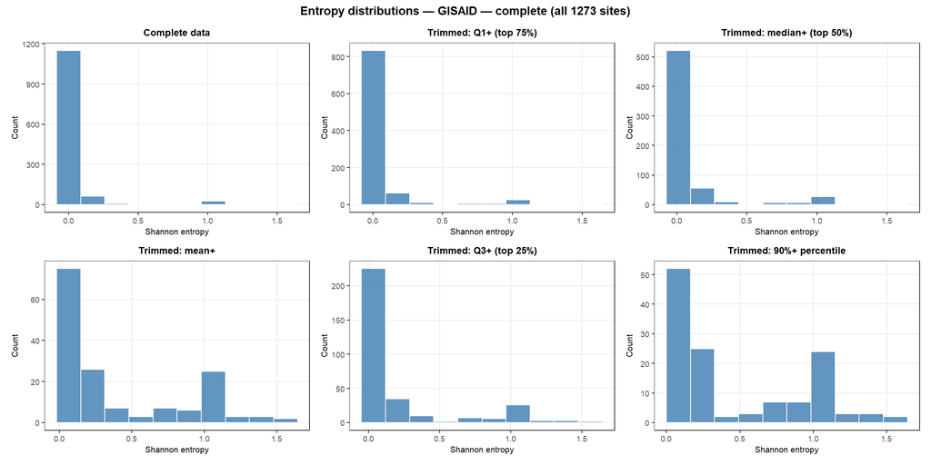

```r
plot_entropy_distributions(Entrop_Vec_GISAID, prob = 0.9,
                           dataset_label = "GISAID \u2014 complete (all 1273 sites)",
                           bins = 10)
```

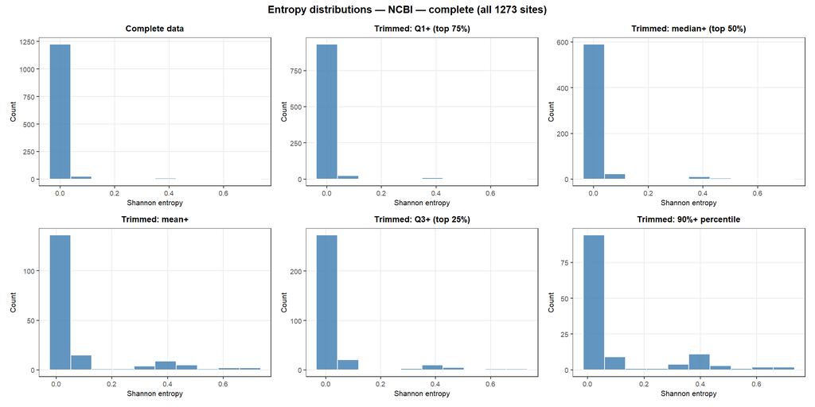

```r
plot_entropy_distributions(Entrop_Vec_NCBI, prob = 0.9,
                           dataset_label = "NCBI \u2014 complete (all 1273 sites)",
                           bins = 10)
```

# 8 Untransformed Analysis (Zeros/Singletons Removed)

GMM is fitted on the zero/singleton-removed entropy vectors. The component with the highest mean entropy is selected as the high-variability cluster.

## 8.1 GISAID

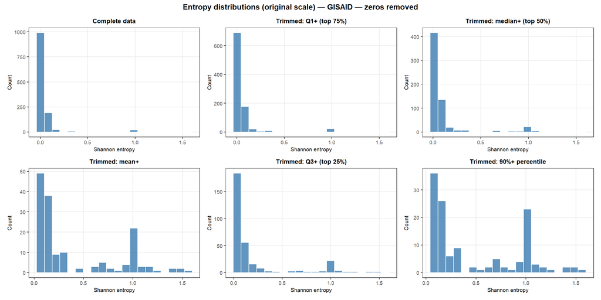

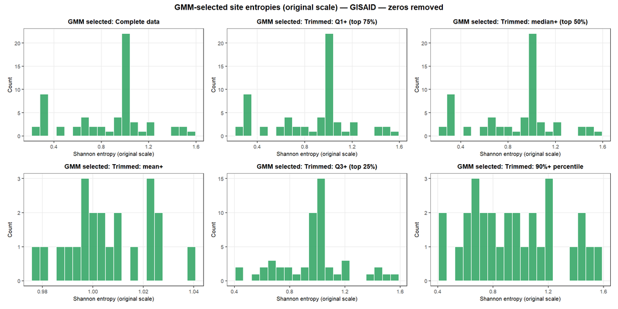

```r
GISAID_gmm_no0S <- gmm_site_selection(
  Entrop_Vec_GISAID_no0S,
  prob             = 0.9,
  transfr          = NULL,
  hist             = TRUE,
  calc_gmm_orig    = TRUE,
  calc_gmm_transfr = FALSE,
  dataset_label    = "GISAID \u2014 zeros removed",
  bins             = 20
)
```

```r
tbl <- save_orig_comparison_table(
  GISAID_gmm_no0S,
  table_caption   = "Site selection \u2014 GISAID, zeros removed, untransformed",
  save_path       = table_path("NonTransformed_GISAID_no0S.html"),
  important_sites = important_sites_gisaid
)
tbl
```

**Site selection — GISAID, zeros removed, untransformed** Reference sites highlighted in yellow. N Overlap and % Overlap relative to N Important.

| Metric | Important | Complete | Top 75% | Top 50% | Top 25% | Mean+ | 90th pct+ |
| --- | --- | --- | --- | --- | --- | --- | --- |
| N | 64 | 62 | 62 | 62 | 51 | 22 | 29 |
| N Overlap | — | 40 | 40 | 40 | 34 | 17 | 17 |
| % Overlap | — | 62.5% | 62.5% | 62.5% | 53.1% | 26.6% | 26.6% |
| N Missed | — | 24 | 24 | 24 | 30 | 47 | 47 |
| Selected Sites | 18, 19, 20, 26, 67, 69, 70, 80 95, 138, 142, 144, 145, 156, 157, 158 190, 211, 212, 215, 222, 241, 242, 243 258, 339, 346, 371, 373, 375, 384, 417 440, 446, 452, 477, 478, 484, 493, 494 496, 498, 501,… | 5, 19, 24, 25, 26, 27, 52, 69 70, 83, 95, 142, 144, 145, 146, 152 156, 157, 158, 183, 213, 222, 252, 339 346, 368, 371, 373, 375, 376, 405, 408 417, 440, 444, 445, 446, 452, 456, 460 477, 478, 484, 48… | 5, 19, 24, 25, 26, 27, 52, 69 70, 83, 95, 142, 144, 145, 146, 152 156, 157, 158, 183, 213, 222, 252, 339 346, 368, 371, 373, 375, 376, 405, 408 417, 440, 444, 445, 446, 452, 456, 460 477, 478, 484, 48… | 5, 19, 24, 25, 26, 27, 52, 69 70, 83, 95, 142, 144, 145, 146, 152 156, 157, 158, 183, 213, 222, 252, 339 346, 368, 371, 373, 375, 376, 405, 408 417, 440, 444, 445, 446, 452, 456, 460 477, 478, 484, 48… | 19, 24, 25, 26, 27, 69, 70, 83 95, 142, 145, 146, 156, 157, 158, 183 213, 252, 339, 346, 368, 371, 373, 375 376, 405, 408, 417, 440, 444, 445, 446 452, 460, 477, 478, 484, 486, 490, 493 498, 501, 505,… | 24, 25, 70, 142, 158, 373, 375, 376 405, 408, 440, 477, 478, 498, 501, 505 655, 679, 764, 796, 954, 969 | 19, 26, 27, 69, 83, 95, 145, 146 156, 157, 183, 213, 252, 339, 346, 368 371, 417, 444, 445, 446, 452, 460, 484 486, 490, 493, 681, 950 |
| Missed Sites | — | 18, 20, 67, 80, 138, 190, 211, 212 215, 241, 242, 243, 258, 384, 494, 496 516, 547, 614, 701, 856, 981, 1027, 1191 | 18, 20, 67, 80, 138, 190, 211, 212 215, 241, 242, 243, 258, 384, 494, 496 516, 547, 614, 701, 856, 981, 1027, 1191 | 18, 20, 67, 80, 138, 190, 211, 212 215, 241, 242, 243, 258, 384, 494, 496 516, 547, 614, 701, 856, 981, 1027, 1191 | 18, 20, 67, 80, 138, 144, 190, 211 212, 215, 222, 241, 242, 243, 258, 384 494, 496, 516, 547, 570, 614, 701, 716 856, 981, 982, 1027, 1118, 1191 | 18, 19, 20, 26, 67, 69, 80, 95 138, 144, 145, 156, 157, 190, 211, 212 215, 222, 241, 242, 243, 258, 339, 346 371, 384, 417, 446, 452, 484, 493, 494 496, 516, 547, 570, 614, 681, 701, 716 856, 950, 981… | 18, 20, 67, 70, 80, 138, 142, 144 158, 190, 211, 212, 215, 222, 241, 242 243, 258, 373, 375, 384, 440, 477, 478 494, 496, 498, 501, 505, 516, 547, 570 614, 655, 679, 701, 716, 764, 796, 856 954, 969, … |

## 8.2 NCBI

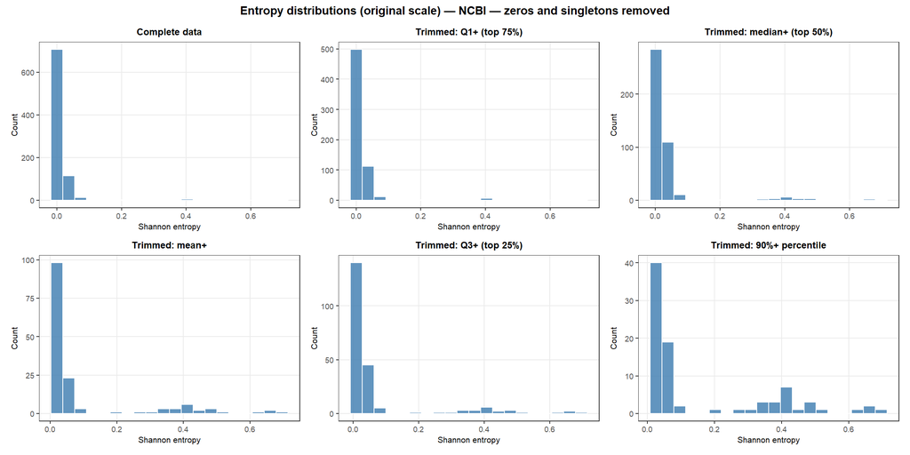

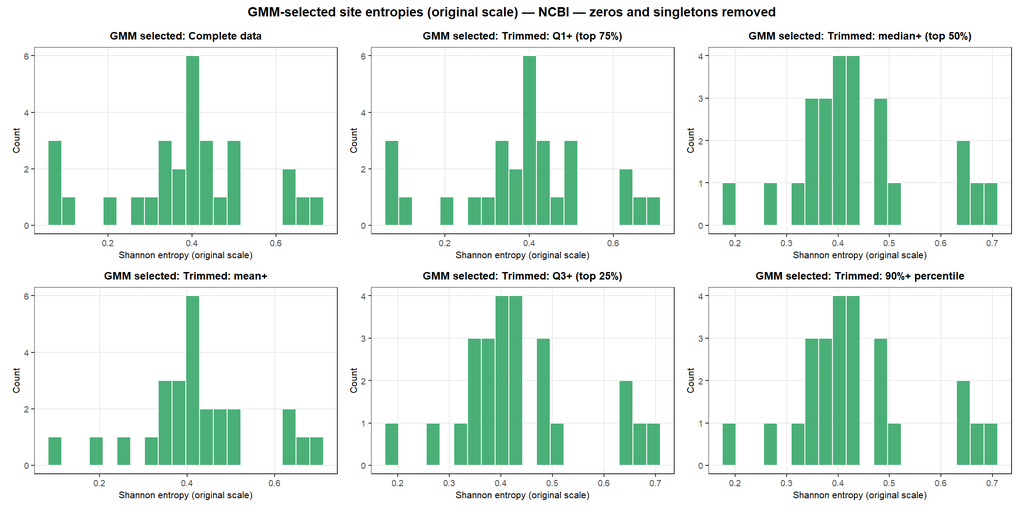

```r
NCBI_gmm_no0S <- gmm_site_selection(
  Entrop_Vec_NCBI_no0S,
  prob             = 0.9,
  transfr          = NULL,
  hist             = TRUE,
  calc_gmm_orig    = TRUE,
  calc_gmm_transfr = FALSE,
  dataset_label    = "NCBI \u2014 zeros and singletons removed",
  bins             = 20
)
```

```r
tbl <- save_orig_comparison_table(
  NCBI_gmm_no0S,
  table_caption   = "Site selection \u2014 NCBI, zeros and singletons removed, untransformed",
  save_path       = table_path("NonTransformed_NCBI_no0S.html"),
  important_sites = important_sites_ncbi
)
tbl
```

**Site selection — NCBI, zeros and singletons removed, untransformed** Reference sites highlighted in yellow. N Overlap and % Overlap relative to N Important.

| Metric | Important | Complete | Top 75% | Top 50% | Top 25% | Mean+ | 90th pct+ |
| --- | --- | --- | --- | --- | --- | --- | --- |
| N | 40 | 29 | 29 | 25 | 25 | 26 | 25 |
| N Overlap | — | 18 | 18 | 16 | 16 | 17 | 16 |
| % Overlap | — | 45.0% | 45.0% | 40.0% | 40.0% | 42.5% | 40.0% |
| N Missed | — | 22 | 22 | 24 | 24 | 23 | 24 |
| Selected Sites | 18, 19, 20, 26, 69, 70, 80, 95 138, 142, 144, 156, 157, 158, 190, 215 222, 241, 242, 243, 258, 384, 417, 452 478, 484, 494, 501, 516, 570, 614, 655 681, 701, 716, 950, 982, 1027, 1118, 1191 | 5, 13, 18, 20, 26, 95, 138, 152 190, 253, 417, 452, 477, 478, 484, 494 501, 614, 655, 677, 681, 688, 701, 716 732, 769, 957, 1027, 1176 | 5, 13, 18, 20, 26, 95, 138, 152 190, 253, 417, 452, 477, 478, 484, 494 501, 614, 655, 677, 681, 688, 701, 716 732, 769, 957, 1027, 1176 | 5, 13, 18, 20, 26, 95, 138, 152 190, 253, 417, 452, 477, 478, 484, 501 614, 655, 677, 681, 701, 732, 957, 1027 1176 | 5, 13, 18, 20, 26, 95, 138, 152 190, 253, 417, 452, 477, 478, 484, 501 614, 655, 677, 681, 701, 732, 957, 1027 1176 | 5, 13, 18, 20, 26, 95, 138, 152 190, 253, 417, 452, 477, 478, 484, 494 501, 614, 655, 677, 681, 701, 732, 957 1027, 1176 | 5, 13, 18, 20, 26, 95, 138, 152 190, 253, 417, 452, 477, 478, 484, 501 614, 655, 677, 681, 701, 732, 957, 1027 1176 |
| Missed Sites | — | 19, 69, 70, 80, 142, 144, 156, 157 158, 215, 222, 241, 242, 243, 258, 384 516, 570, 950, 982, 1118, 1191 | 19, 69, 70, 80, 142, 144, 156, 157 158, 215, 222, 241, 242, 243, 258, 384 516, 570, 950, 982, 1118, 1191 | 19, 69, 70, 80, 142, 144, 156, 157 158, 215, 222, 241, 242, 243, 258, 384 494, 516, 570, 716, 950, 982, 1118, 1191 | 19, 69, 70, 80, 142, 144, 156, 157 158, 215, 222, 241, 242, 243, 258, 384 494, 516, 570, 716, 950, 982, 1118, 1191 | 19, 69, 70, 80, 142, 144, 156, 157 158, 215, 222, 241, 242, 243, 258, 384 516, 570, 716, 950, 982, 1118, 1191 | 19, 69, 70, 80, 142, 144, 156, 157 158, 215, 222, 241, 242, 243, 258, 384 494, 516, 570, 716, 950, 982, 1118, 1191 |

# 9 Transformation Experiments

All transformations are applied exclusively to the zero/singleton-removed vectors. For each transformation, the GMM is fitted on the transformed scale; selected sites are reported back on the original entropy scale for interpretability.

## 9.1 Box-Cox Lambda Exploration

$$x^{(\lambda)} = \begin{cases} \dfrac{x^{\lambda} - 1}{\lambda} &
\text{if } \lambda \neq 0 \\[6pt] \ln(x) & \text{if } \lambda = 0
\end{cases}$$

Nine equally spaced values of λ across [−2, 2] are applied to the zero/singleton-removed vectors to identify which value most effectively yield the most symmetric shape of the distribution.

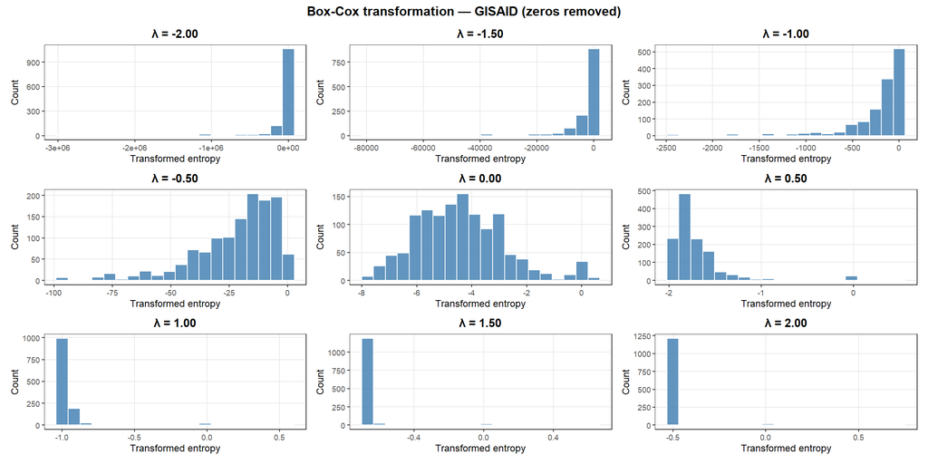

```r
boxcox_transform <- function(x, lambda) {
  if (lambda == 0) log(x) else (x^lambda - 1) / lambda
}
lambdas <- seq(-2, 2, length.out = 9L)

plot_boxcox_grid <- function(ev, dataset_label) {
  plots <- lapply(seq_along(lambdas), function(i) {
    lam  <- lambdas[i]
    data <- boxcox_transform(ev, lam)
    ggplot2::ggplot(data.frame(x = data), ggplot2::aes(x = x)) +
      ggplot2::geom_histogram(fill = "steelblue", colour = "white",
                              alpha = 0.85, bins = 20L) +
      ggplot2::labs(title = sprintf("\u03bb = %.2f", lam),
                    x = "Transformed entropy", y = "Count") +
      ggplot2::theme_bw(base_size = 9) +
      ggplot2::theme(plot.title       = ggplot2::element_text(face = "bold",
                                                               hjust = 0.5),
                     panel.grid.minor = ggplot2::element_blank())
  })
  print(
    patchwork::wrap_plots(plots, ncol = 3L) +
      patchwork::plot_annotation(
        title = sprintf("Box-Cox transformation \u2014 %s", dataset_label),
        theme = ggplot2::theme(plot.title = ggplot2::element_text(
          face = "bold", hjust = 0.5, size = 12)))
  )
}

plot_boxcox_grid(Entrop_Vec_GISAID_no0S, "GISAID (zeros removed)")
```

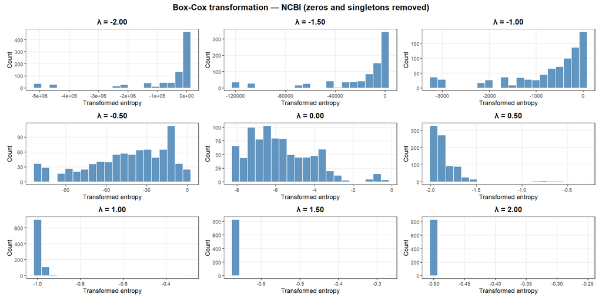

```r
plot_boxcox_grid(Entrop_Vec_NCBI_no0S,   "NCBI (zeros and singletons removed)")
```

## 9.2 Log1p

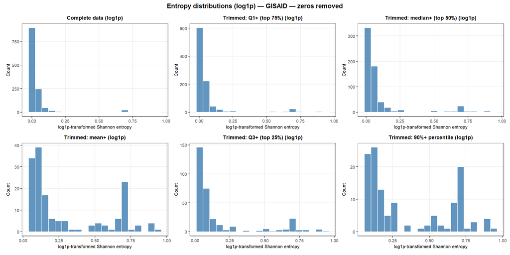

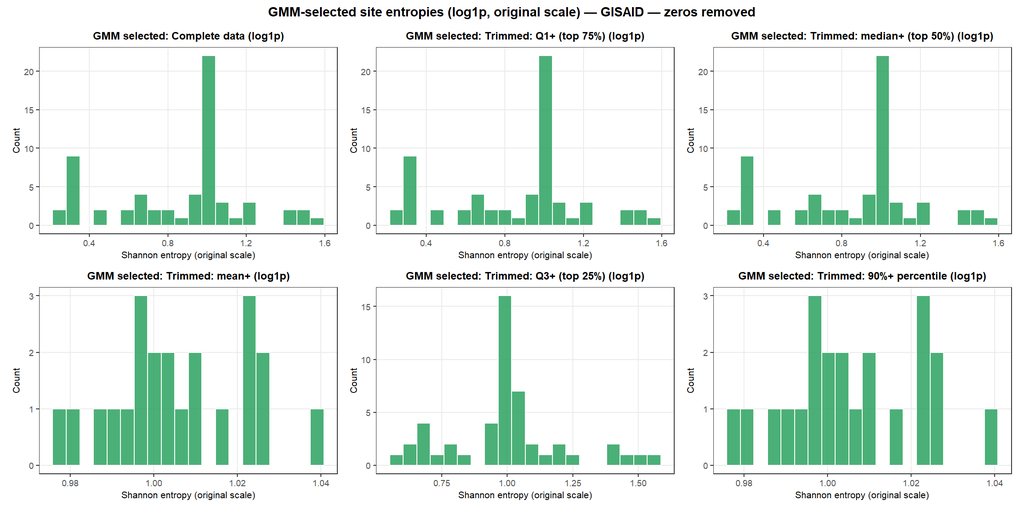

```r
GISAID_log1p_no0S <- gmm_site_selection(
  Entrop_Vec_GISAID_no0S, transfr = scales::log1p_trans(),
  prob = 0.9, hist = TRUE, calc_gmm_orig = FALSE, calc_gmm_transfr = TRUE,
  dataset_label = "GISAID \u2014 zeros removed", bins = 20
)
```

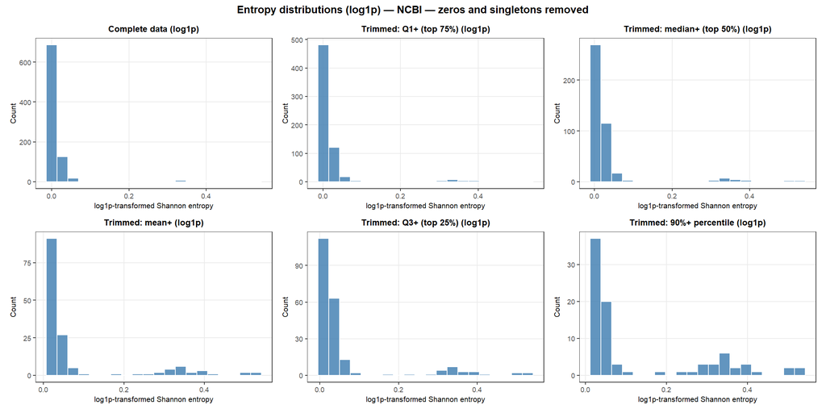

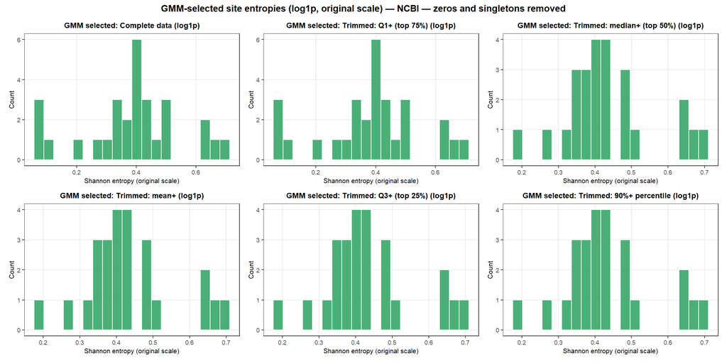

```r
NCBI_log1p_no0S <- gmm_site_selection(
  Entrop_Vec_NCBI_no0S, transfr = scales::log1p_trans(),
  prob = 0.9, hist = TRUE, calc_gmm_orig = FALSE, calc_gmm_transfr = TRUE,
  dataset_label = "NCBI \u2014 zeros and singletons removed", bins = 20
)
```

```r
save_transformed_comparison_table(
  GISAID_log1p_no0S,
  "Site selection \u2014 GISAID, zeros removed, Log1p",
  table_path("Log1p_GISAID_no0S.html"), important_sites_gisaid
)

save_transformed_comparison_table(
  NCBI_log1p_no0S,
  "Site selection \u2014 NCBI, zeros and singletons removed, Log1p",
  table_path("Log1p_NCBI_no0S.html"), important_sites_ncbi
)
```

## 9.3 Log1p∘Log1p (Double Compression)

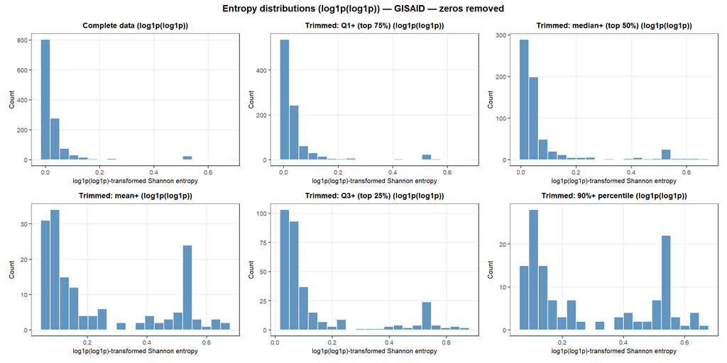

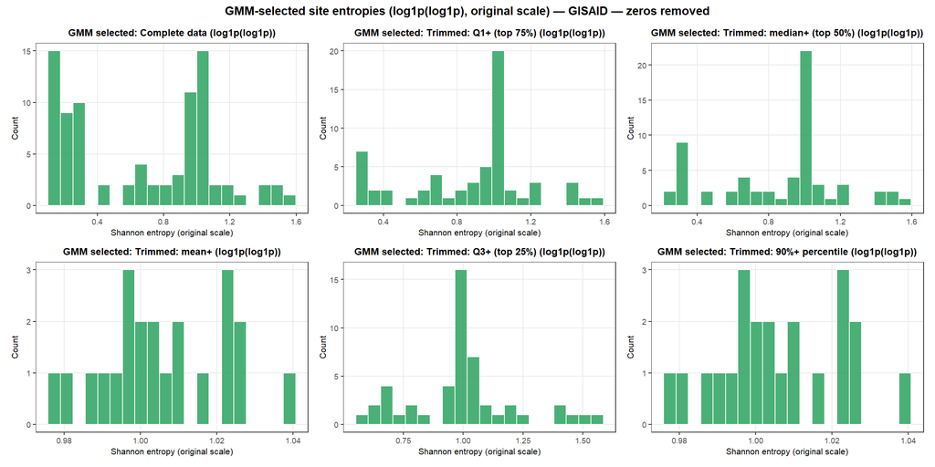

```r
GISAID_loglog_no0S <- gmm_site_selection(
  Entrop_Vec_GISAID_no0S, transfr = loglog1p1p_trans,
  prob = 0.9, hist = TRUE, calc_gmm_orig = FALSE, calc_gmm_transfr = TRUE,
  dataset_label = "GISAID \u2014 zeros removed", bins = 20
)
```

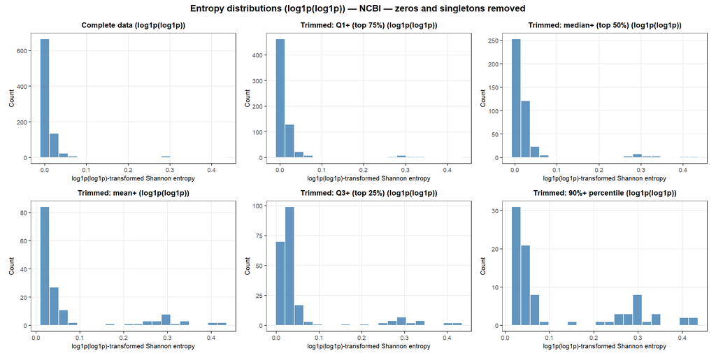

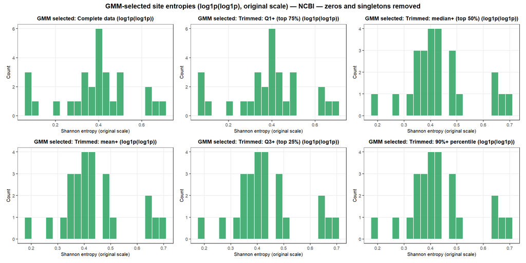

```r
NCBI_loglog_no0S <- gmm_site_selection(
  Entrop_Vec_NCBI_no0S, transfr = loglog1p1p_trans,
  prob = 0.9, hist = TRUE, calc_gmm_orig = FALSE, calc_gmm_transfr = TRUE,
  dataset_label = "NCBI \u2014 zeros and singletons removed", bins = 20
)
```

```r
save_transformed_comparison_table(
  GISAID_loglog_no0S,
  "Site selection \u2014 GISAID, zeros removed, Log1p\u2218Log1p",
  table_path("LogLog_GISAID_no0S.html"), important_sites_gisaid
)

save_transformed_comparison_table(
  NCBI_loglog_no0S,
  "Site selection \u2014 NCBI, zeros and singletons removed, Log1p\u2218Log1p",
  table_path("LogLog_NCBI_no0S.html"), important_sites_ncbi
)
```

## 9.4 Square Root

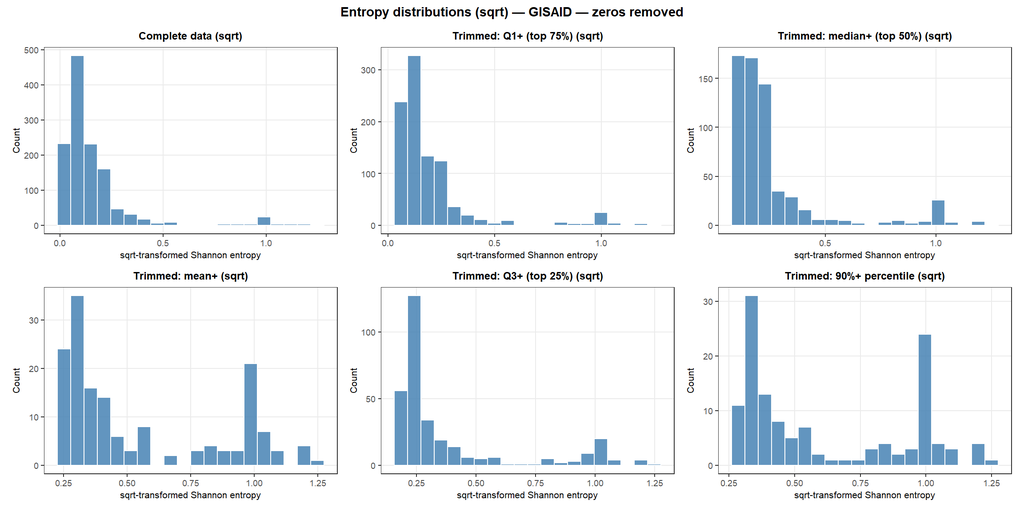

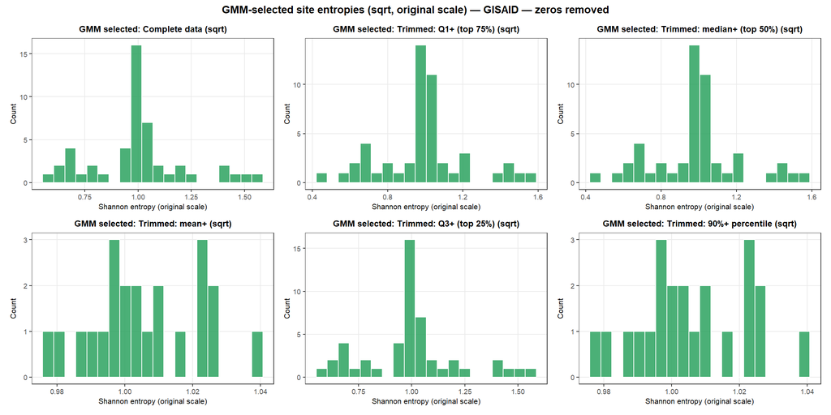

```r
GISAID_sqrt_no0S <- gmm_site_selection(
  Entrop_Vec_GISAID_no0S, transfr = scales::sqrt_trans(),
  prob = 0.9, hist = TRUE, calc_gmm_orig = FALSE, calc_gmm_transfr = TRUE,
  dataset_label = "GISAID \u2014 zeros removed", bins = 20
)
```

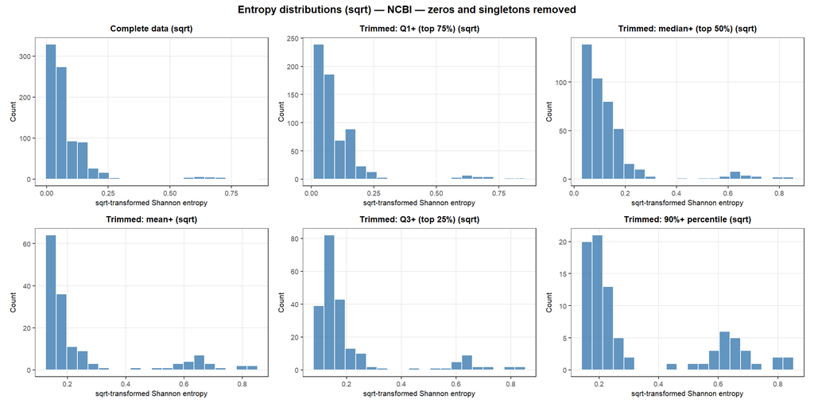

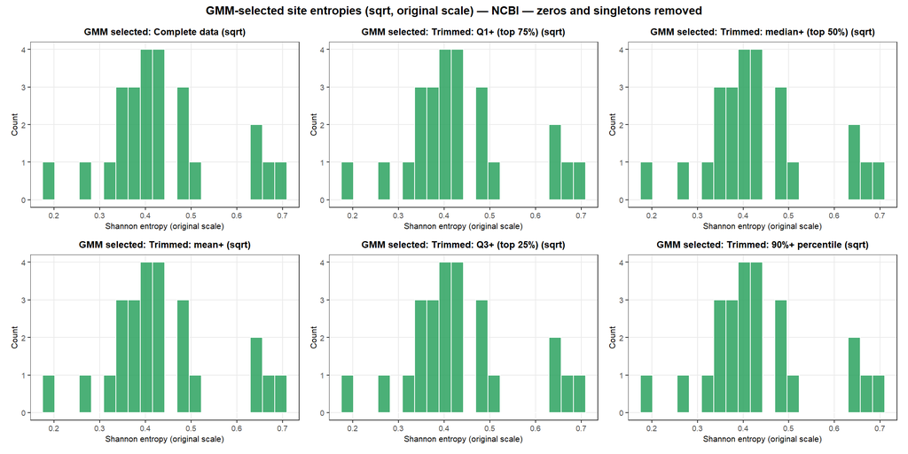

```r
NCBI_sqrt_no0S <- gmm_site_selection(
  Entrop_Vec_NCBI_no0S, transfr = scales::sqrt_trans(),
  prob = 0.9, hist = TRUE, calc_gmm_orig = FALSE, calc_gmm_transfr = TRUE,
  dataset_label = "NCBI \u2014 zeros and singletons removed", bins = 20
)
```

```r
save_transformed_comparison_table(
  GISAID_sqrt_no0S,
  "Site selection \u2014 GISAID, zeros removed, Square root",
  table_path("Sqrt_GISAID_no0S.html"), important_sites_gisaid
)

save_transformed_comparison_table(
  NCBI_sqrt_no0S,
  "Site selection \u2014 NCBI, zeros and singletons removed, Square root",
  table_path("Sqrt_NCBI_no0S.html"), important_sites_ncbi
)
```

## 9.5 Reciprocal

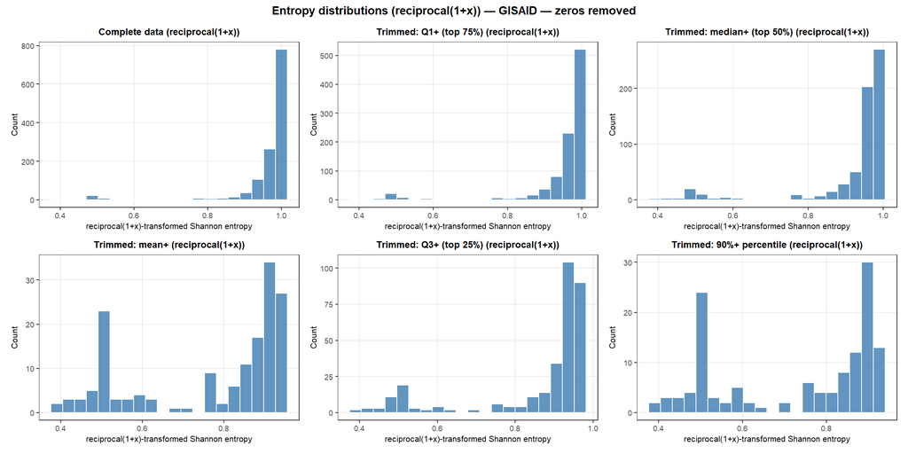

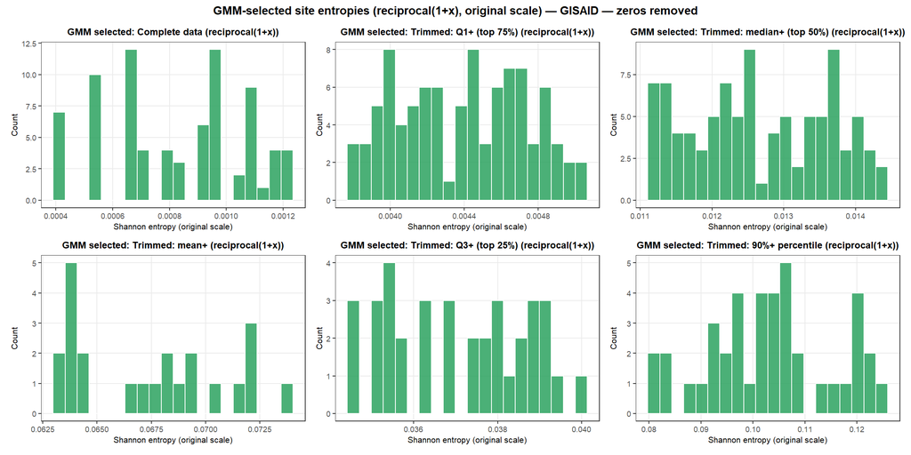

```r
GISAID_recip_no0S <- gmm_site_selection(
  Entrop_Vec_GISAID_no0S, transfr = reciprocal_trans,
  prob = 0.9, hist = TRUE, calc_gmm_orig = FALSE, calc_gmm_transfr = TRUE,
  dataset_label = "GISAID \u2014 zeros removed", bins = 20
)
```

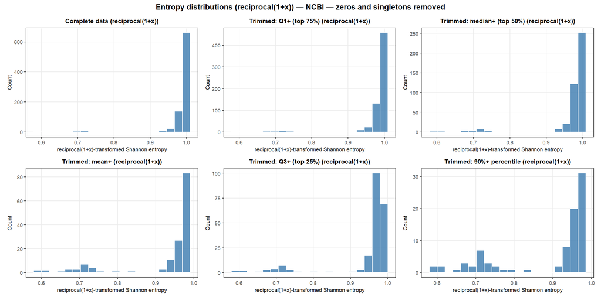

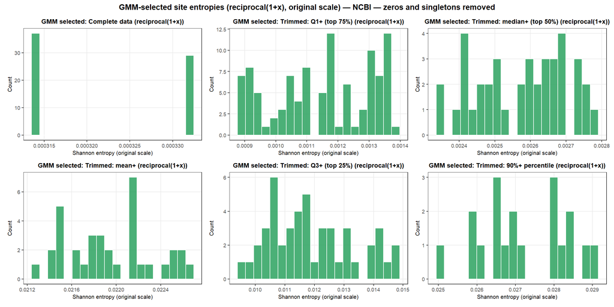

```r
NCBI_recip_no0S <- gmm_site_selection(
  Entrop_Vec_NCBI_no0S, transfr = reciprocal_trans,
  prob = 0.9, hist = TRUE, calc_gmm_orig = FALSE, calc_gmm_transfr = TRUE,
  dataset_label = "NCBI \u2014 zeros and singletons removed", bins = 20
)
```

```r
save_transformed_comparison_table(
  GISAID_recip_no0S,
  "Site selection \u2014 GISAID, zeros removed, Reciprocal",
  table_path("Reciprocal_GISAID_no0S.html"), important_sites_gisaid
)

save_transformed_comparison_table(
  NCBI_recip_no0S,
  "Site selection \u2014 NCBI, zeros and singletons removed, Reciprocal",
  table_path("Reciprocal_NCBI_no0S.html"), important_sites_ncbi
)
```

## 9.6 Box-Cox (λ = −0.05)

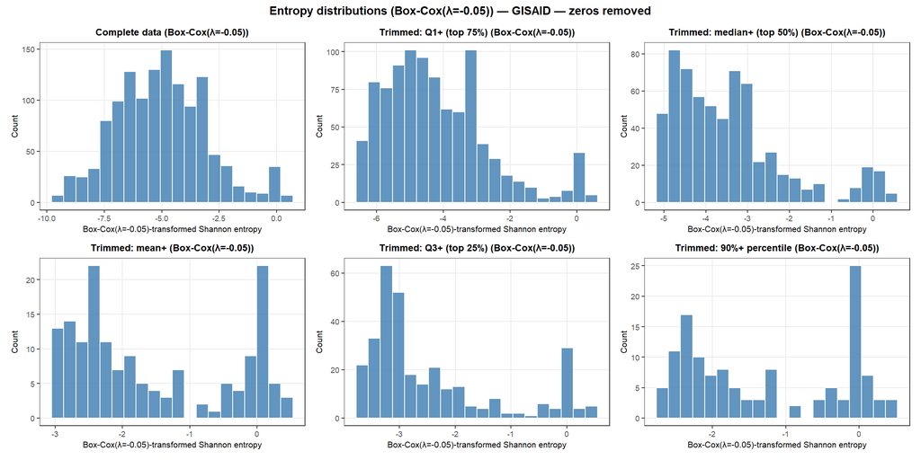

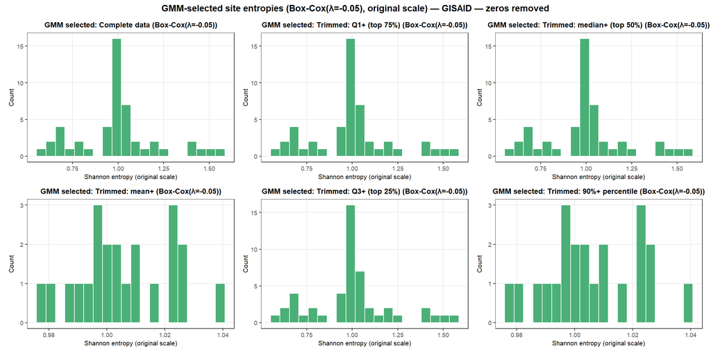

```r
bc_trans <- boxcox_trans(lambda = -0.05)

GISAID_bc_no0S <- gmm_site_selection(
  Entrop_Vec_GISAID_no0S, transfr = bc_trans,
  prob = 0.9, hist = TRUE, calc_gmm_orig = FALSE, calc_gmm_transfr = TRUE,
  dataset_label = "GISAID \u2014 zeros removed", bins = 20
)
```

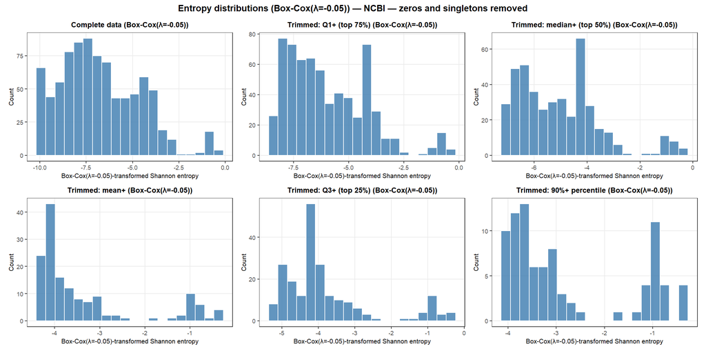

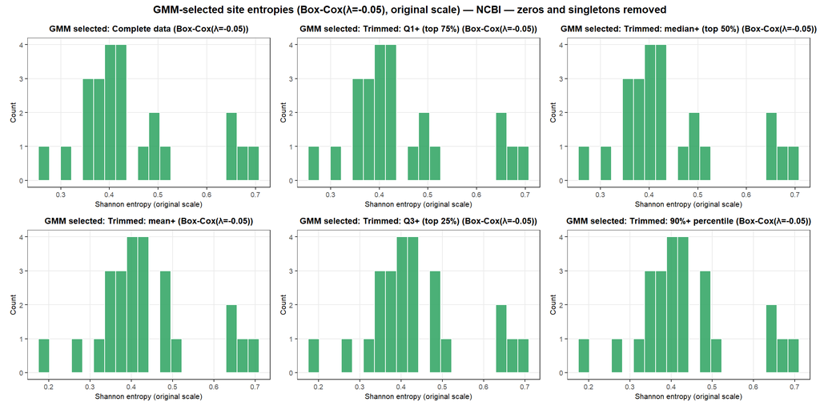

```r
NCBI_bc_no0S <- gmm_site_selection(
  Entrop_Vec_NCBI_no0S, transfr = bc_trans,
  prob = 0.9, hist = TRUE, calc_gmm_orig = FALSE, calc_gmm_transfr = TRUE,
  dataset_label = "NCBI \u2014 zeros and singletons removed", bins = 20
)
```

```r
save_transformed_comparison_table(
  GISAID_bc_no0S,
  "Site selection \u2014 GISAID, zeros removed, Box-Cox (\u03bb = \u22120.05)",
  table_path("BoxCox_GISAID_no0S.html"), important_sites_gisaid
)

save_transformed_comparison_table(
  NCBI_bc_no0S,
  "Site selection \u2014 NCBI, zeros and singletons removed, Box-Cox (\u03bb = \u22120.05)",
  table_path("BoxCox_NCBI_no0S.html"), important_sites_ncbi
)
```

## 9.7 Log (natural log)

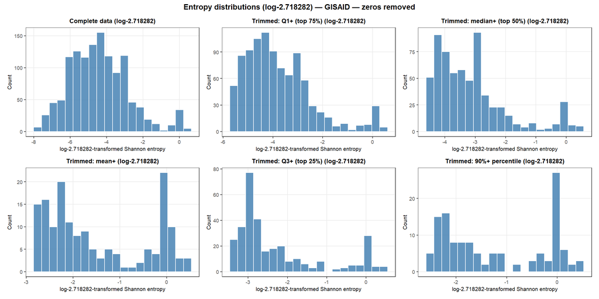

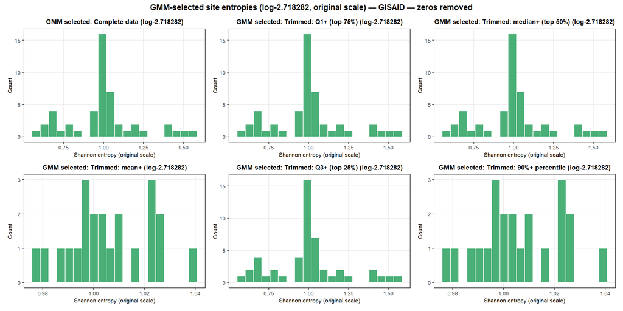

```r
GISAID_log_no0S <- gmm_site_selection(
  Entrop_Vec_GISAID_no0S, transfr = scales::log_trans(),
  prob = 0.9, hist = TRUE, calc_gmm_orig = FALSE, calc_gmm_transfr = TRUE,
  dataset_label = "GISAID \u2014 zeros removed", bins = 20
)
```

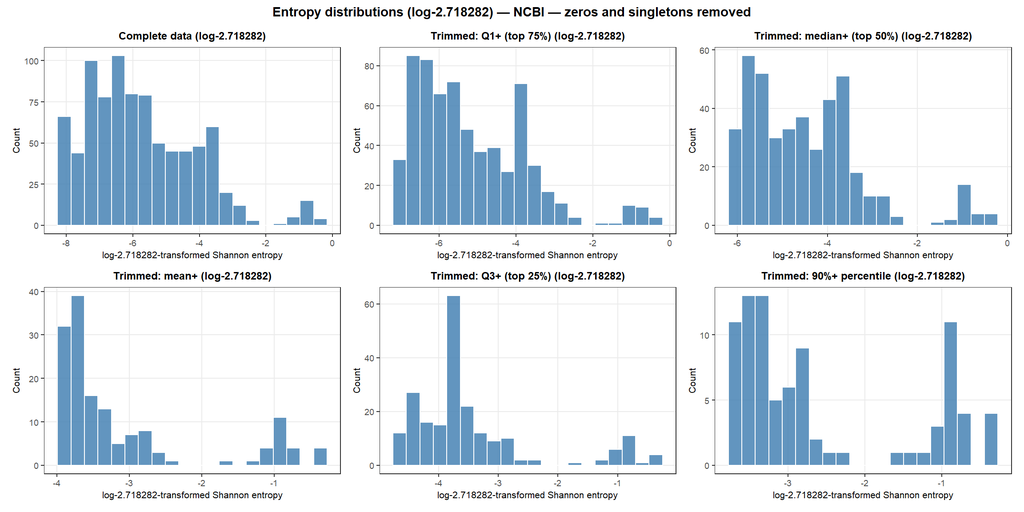

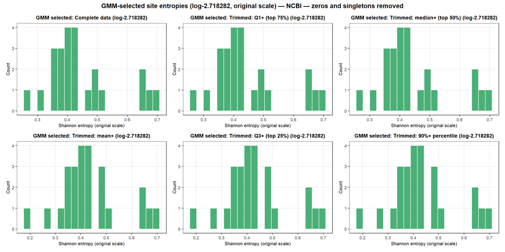

```r
NCBI_log_no0S <- gmm_site_selection(
  Entrop_Vec_NCBI_no0S, transfr = scales::log_trans(),
  prob = 0.9, hist = TRUE, calc_gmm_orig = FALSE, calc_gmm_transfr = TRUE,
  dataset_label = "NCBI \u2014 zeros and singletons removed", bins = 20
)
```

```r
save_transformed_comparison_table(
  GISAID_log_no0S,
  "Site selection \u2014 GISAID, zeros removed, Log",
  table_path("Log_GISAID_no0S.html"), important_sites_gisaid
)

save_transformed_comparison_table(
  NCBI_log_no0S,
  "Site selection \u2014 NCBI, zeros and singletons removed, Log",
  table_path("Log_NCBI_no0S.html"), important_sites_ncbi
)
```

# 10 Summary: % Overlap Across All Transformations

The tables below consolidate the percentage of VOC reference sites recovered by each GMM subset across all transformations. Cell colour intensity is proportional to overlap — deeper green indicates higher recovery. The maximum value in each transformation column is shown in bold.

## 10.1 GISAID summary table

```r
gisaid_results <- list(
  "Untransformed"    = GISAID_gmm_no0S,
  "Log1p"            = GISAID_log1p_no0S,
  "Log1p\u2218Log1p" = GISAID_loglog_no0S,
  "Square root"      = GISAID_sqrt_no0S,
  "Reciprocal"       = GISAID_recip_no0S,
  "Box-Cox"          = GISAID_bc_no0S,
  "Log"              = GISAID_log_no0S
)

tbl_summary_gisaid <- generate_summary_table(
  results_list    = gisaid_results,
  important_sites = important_sites_gisaid,
  table_caption   = "Summary: % overlap with GISAID VOC reference sites (Alpha / Beta / Gamma / Delta / Omicron) by GMM subset and transformation",
  save_path       = table_path("Summary_GISAID.html")
)
tbl_summary_gisaid
```

**Summary: % overlap with GISAID VOC reference sites (Alpha / Beta / Gamma / Delta / Omicron) by GMM subset and transformation** Cell values: % overlap with VOC reference sites. Colour intensity proportional to overlap percentage.

| Subset | Untransformed | Log1p | Log1p∘Log1p | Square root | Reciprocal | Box-Cox | Log |
| --- | --- | --- | --- | --- | --- | --- | --- |
| Complete | 62.5% | 62.5% | 76.6% | 51.6% | 0.0% | 51.6% | 51.6% |
| Top 75% | 62.5% | 62.5% | 62.5% | 51.6% | 0.0% | 51.6% | 51.6% |
| Top 50% | 62.5% | 62.5% | 62.5% | 51.6% | 1.6% | 51.6% | 51.6% |
| Top 25% | 53.1% | 51.6% | 51.6% | 51.6% | 0.0% | 51.6% | 51.6% |
| Mean+ | 26.6% | 26.6% | 26.6% | 26.6% | 1.6% | 26.6% | 26.6% |
| 90th pct+ | 26.6% | 26.6% | 26.6% | 26.6% | 12.5% | 26.6% | 26.6% |

## 10.2 NCBI summary table

```r
ncbi_results <- list(
  "Untransformed"    = NCBI_gmm_no0S,
  "Log1p"            = NCBI_log1p_no0S,
  "Log1p\u2218Log1p" = NCBI_loglog_no0S,
  "Square root"      = NCBI_sqrt_no0S,
  "Reciprocal"       = NCBI_recip_no0S,
  "Box-Cox"          = NCBI_bc_no0S,
  "Log"              = NCBI_log_no0S
)

tbl_summary_ncbi <- generate_summary_table(
  results_list    = ncbi_results,
  important_sites = important_sites_ncbi,
  table_caption   = "Summary: % overlap with NCBI VOC reference sites (Alpha / Beta / Gamma / Delta) by GMM subset and transformation",
  save_path       = table_path("Summary_NCBI.html")
)
tbl_summary_ncbi
```

**Summary: % overlap with NCBI VOC reference sites (Alpha / Beta / Gamma / Delta) by GMM subset and transformation** Cell values: % overlap with VOC reference sites. Colour intensity proportional to overlap percentage.

| Subset | Untransformed | Log1p | Log1p∘Log1p | Square root | Reciprocal | Box-Cox | Log |
| --- | --- | --- | --- | --- | --- | --- | --- |
| Complete | 45.0% | 45.0% | 45.0% | 40.0% | 0.0% | 37.5% | 37.5% |
| Top 75% | 45.0% | 45.0% | 45.0% | 40.0% | 0.0% | 37.5% | 37.5% |
| Top 50% | 40.0% | 40.0% | 40.0% | 40.0% | 2.5% | 37.5% | 37.5% |
| Top 25% | 40.0% | 40.0% | 40.0% | 40.0% | 7.5% | 40.0% | 40.0% |
| Mean+ | 42.5% | 40.0% | 40.0% | 40.0% | 2.5% | 40.0% | 40.0% |
| 90th pct+ | 40.0% | 40.0% | 40.0% | 40.0% | 7.5% | 40.0% | 40.0% |

# References

Cover, Thomas M., and Joy A. Thomas. 2006. *Elements of Information Theory*. 2nd ed. Wiley.

Fraley, Chris, and Adrian E. Raftery. 2002. “Model-Based Clustering, Discriminant Analysis, and Density Estimation.” *Journal of the American Statistical Association* 97 (458): 611–31.

Hennig, Christian. 2015. “What Are the True Clusters?” *Pattern Recognition Letters* 64: 53–62. https://doi.org/10.1016/j.patrec.2015.04.009.

Korber, Bette, Will M. Fischer, Sandrasegaram Gnanakaran, et al. 2020. “Tracking Changes in SARS-CoV-2 Spike: Evidence That D614G Increases Infectivity of the COVID-19 Virus.” *Cell* 182 (4): 812–27. https://doi.org/10.1016/j.cell.2020.06.043.

McLachlan, Geoffrey, and David Peel. 2000. *Finite Mixture Models*. Wiley.

Shannon, Claude E. 1948. “A Mathematical Theory of Communication.” *Bell System Technical Journal* 27 (3): 379–423. https://doi.org/10.1002/j.1538-7305.1948.tb01338.x.